# Data_Learning

2025-04-14

```r
options(repos = c(CRAN = "https://cran.rstudio.com"))
install.packages("caret")
install.packages("pROC")
library(pROC)
```

```r
library(rpart)
library(rpart.plot)
library(caret)
library(ggplot2)
library(randomForest)
library(randomForestSRC)
library(xgboost)
library(gam)
library(mgcv)
library(Amelia)
```

#Task 1 #yi =(⌊10∗x1+1⌋+⌊10∗x2+1⌋) mod2, #where ⌊·⌋ is the floor function: ⌊x⌋ = max{m ∈ Z|m ≤ x}.

```r
set.seed(123)
#1a
n=1000000
X_1=runif(n, min=0, max=1)
X_2=runif(n, min=0, max=1)
Y=(floor(10*X_1+1)+floor(10*X_2+1))%%2
```

#(b) Convert the variable y into a factor type and create a data frame with y,x1,x2.

```r
#1b
y=factor(Y)
my_data=data.frame(y, X_1, X_2)
```

#(c) Plot the data on a scatter plot, where X1 is on the horizontal axis, X2 is on the vertical axis, and the colour of the data is based on the class Y .

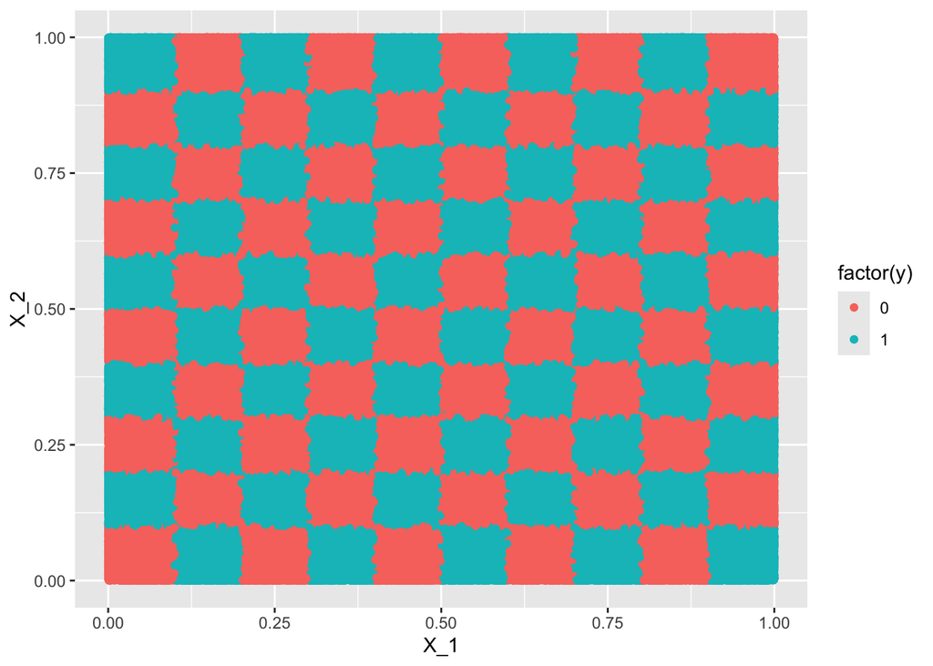

```r
#1c
ggplot(my_data, mapping=aes(x=X_1,y=X_2,color=factor(y)))+geom_point()
```

#(d) The image exhibits a pattern resembling a chessboard, which results from the binary variable yi being influenced by two independent variables, x1 and x2. The condition for yi to be 0 is when both ⌊10∗x1+1⌋ and ⌊10∗x2+1⌋ are either odd or even numbers. Conversely, yi is set to 1 when one is odd and the other is even. Since the independent variables x1 and x2 are identically distributed and processed similarly, the image demonstrates a symmetrical pattern with sections akin to a chessboard.

#(e) Given that yi is a binary variable, to mitigate the impact of sample randomness on model fitting, I opted for stratified sampling. From the total samples of yi=0 and yi=1, 5000 samples were extracted from each. These samples were then divided into training and testing datasets in a 7:3 ratio. Finally, a parameter for 10-fold cross-validation was established for subsequent model fitting.

```r
#1e
n_samples=10000
#5000 for each group
n_samples_per_layer=round(n_samples*table(my_data$y)/n)
#Group by y, randomly sample each group separately, and then combine the results into a new data frame
selected_data=do.call(rbind,
                        lapply(split(my_data, my_data$y), function(df)
                          df[sample(nrow(df),
                                    n_samples_per_layer[df$y[1]],
                                    replace = FALSE),]))
train_indices=sample(1:nrow(selected_data), 0.7 * nrow(selected_data))
train_data=selected_data[train_indices, ]
test_data=selected_data[-train_indices, ]
train_control=trainControl(method = "cv", number = 10)
```

#(f) As mentioned in 1 (d), the value of yi is determined by the parity of the two terms on the right side of the equation, which in turn depends on the values of x1 and x2. Whenever the value of one of these variables changes by 0.1, the parity of the corresponding term changes. This results in the two-dimensional plane, formed by these variables, being divided into 100 regions in a 10x10 grid. Therefore, a decision tree model can effectively determine the split thresholds at each node by learning from the training data. It utilizes the value ranges of x1 and x2 to partition the feature space, thoroughly learning the Data Generating Process (DGP) to achieve excellent classification results. The accuracy indeed reached an impressive 95.9%, demonstrating that the decision tree model can effectively learn the DGP.

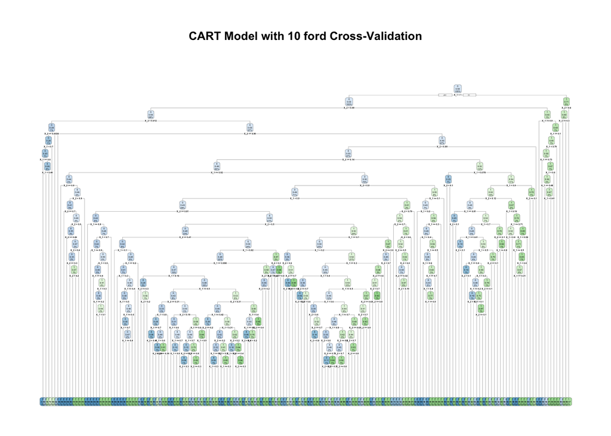

```r
#1fCART
CART_cv=train(y ~ X_1 + X_2, data = train_data,
              method = "rpart",
              parms = list(split = "gini"),
              trControl = train_control,
              tuneGrid = data.frame(cp = 0.0001))
rpart.plot(CART_cv$finalModel, main="CART Model with 10 ford Cross-Validation")
```

```r
CARTpred=predict(CART_cv, newdata = test_data)
sstCART=sum(CARTpred == test_data$y)/nrow(test_data)
print(sstCART)
```

```
## [1] 0.9586667
```

```r
#1g random forest
random_forest=randomForest(y~X_1+X_2,method="class",
                    trControl = train_control,
                    data=train_data,ntree = 150)
rfpred=predict(random_forest, newdata=test_data, outcome.target=class)
sstrf=sum(rfpred==test_data$y)/nrow(test_data)
sstrf
```

```
## [1] 0.975
```

#(h) Compared to decision tree models, the advantage of boosting lies in its ability to increase accuracy and capture more complex data patterns by combining multiple weak learners (e.g., decision trees). In contrast to random forests, the boosting model progressively corrects preceding models to improve performance, resulting in higher accuracy, adaptability, and flexibility. However, its proficiency in signal detection, including the capture of weak signals and noise, can lead to a propensity for overfitting. In this case, the highest prediction accuracy achieved by boosting was approximately 98%, the highest among the three models discussed.

```r
#1h
train_matrix=as.matrix(train_data[, -which(names(train_data) == "y")])
test_matrix=as.matrix(test_data[, -which(names(test_data) == "y")])
label=as.numeric(train_data$y)-1
xgb_model=xgboost(data = train_matrix, label = label,
                  trControl = train_control,
                  nrounds = 100,
                  eta=0.1,max_depth=10, objective="binary:hinge")
```

```
## [21:34:22] WARNING: src/learner.cc:767:
## Parameters: { "trControl" } are not used.
##
```

```r
pre=predict(xgb_model,test_matrix)
sstxgb=mean(pre==test_data$y)
sstxgb
```

```
## [1] 0.98
```

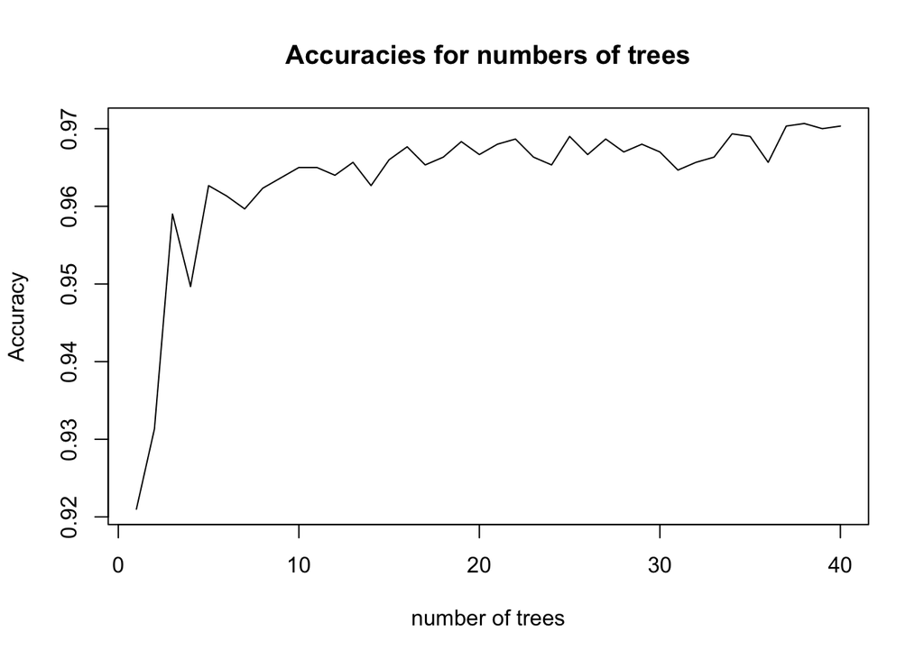

```r
#1i
accuracy_1=numeric()
for (i in 1:40){
  random_forest=rfsrc(y~X_1+X_2,method="class",
                      trControl = train_control,
                      data=train_data,ntree = i)
  rfpred=predict(random_forest, newdata=test_data, outcome.target=class)
  accuracy_1[i]=sum(rfpred$class==test_data$y)/nrow(test_data)
}
accuracy_2=numeric()
for (i in 1:30){
  random_forest=rfsrc(y~X_1+X_2,method="class",
                      trControl = train_control,
                      data=train_data,ntree = 40,
                      nodedepth=i)
  rfpred=predict(random_forest, newdata=test_data, outcome.target=class)
  accuracy_2[i]=sum(rfpred$class==test_data$y)/nrow(test_data)
}
par(mfrow = c(1, 1))
plot(accuracy_1, main = "Accuracies for numbers of trees",
     xlab = "number of trees", ylab = "Accuracy", type = 'l')
```

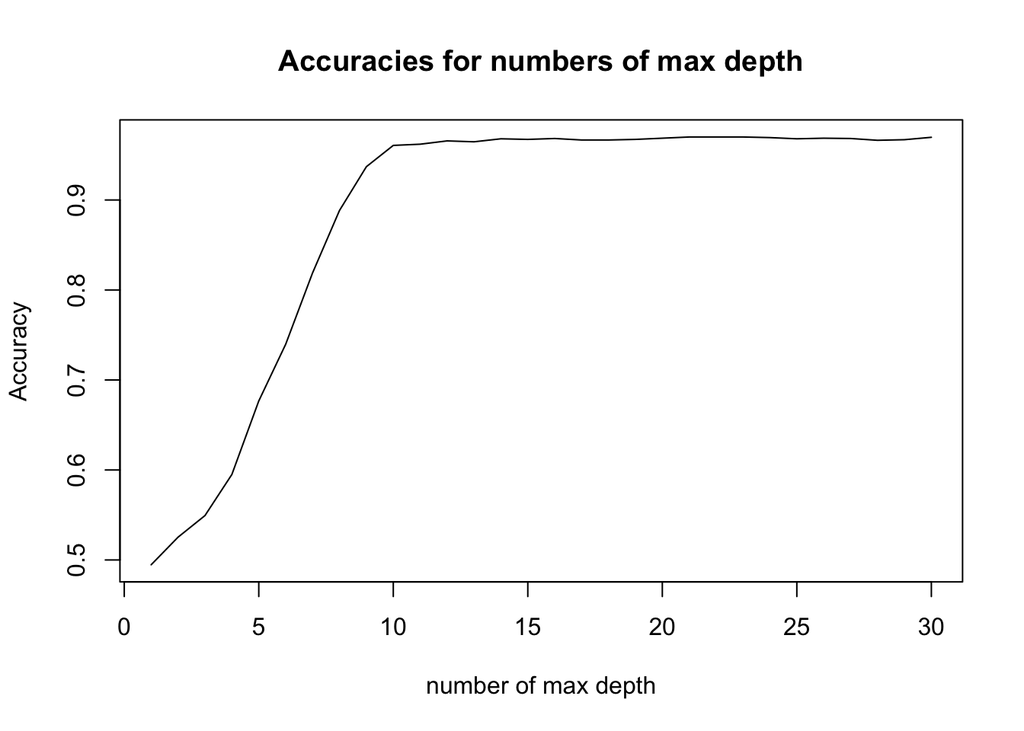

```r
plot(accuracy_2, main = "Accuracies for numbers of max depth",
     xlab = "number of max depth", ylab = "Accuracy", type='l')
```

#Task 2

```r
bank=read.csv("/Users/jiyuzhang/Desktop/Leeds\ Master/semester_1/Learningfromdata/Coursework/Portuguese_Bank.csv", header = TRUE)
```

```r
#a
summary(bank)
```

```
##       age            job              marital           education
##  Min.   :17.00   Length:32950       Length:32950       Length:32950
##  1st Qu.:32.00   Class :character   Class :character   Class :character
##  Median :38.00   Mode  :character   Mode  :character   Mode  :character
##  Mean   :40.01
##  3rd Qu.:47.00
##  Max.   :98.00
##    default            housing              loan             contact
##  Length:32950       Length:32950       Length:32950       Length:32950
##  Class :character   Class :character   Class :character   Class :character
##  Mode  :character   Mode  :character   Mode  :character   Mode  :character
##
##
##
##     month           day_of_week           duration         campaign
##  Length:32950       Length:32950       Min.   :   0.0   Min.   : 1.000
##  Class :character   Class :character   1st Qu.: 103.0   1st Qu.: 1.000
##  Mode  :character   Mode  :character   Median : 180.0   Median : 2.000
##                                        Mean   : 258.1   Mean   : 2.561
##                                        3rd Qu.: 319.0   3rd Qu.: 3.000
##                                        Max.   :4918.0   Max.   :56.000
##      pdays          previous        poutcome              y
##  Min.   :  0.0   Min.   :0.0000   Length:32950       Length:32950
##  1st Qu.:999.0   1st Qu.:0.0000   Class :character   Class :character
##  Median :999.0   Median :0.0000   Mode  :character   Mode  :character
##  Mean   :962.1   Mean   :0.1747
##  3rd Qu.:999.0   3rd Qu.:0.0000
##  Max.   :999.0   Max.   :7.0000
```

```r
length(bank$duration)
```

```
## [1] 32950
```

```r
length(bank$campaign)
```

```
## [1] 32950
```

```r
length(bank$pdays)
```

```
## [1] 32950
```

```r
length(bank$previous)
```

```
## [1] 32950
```

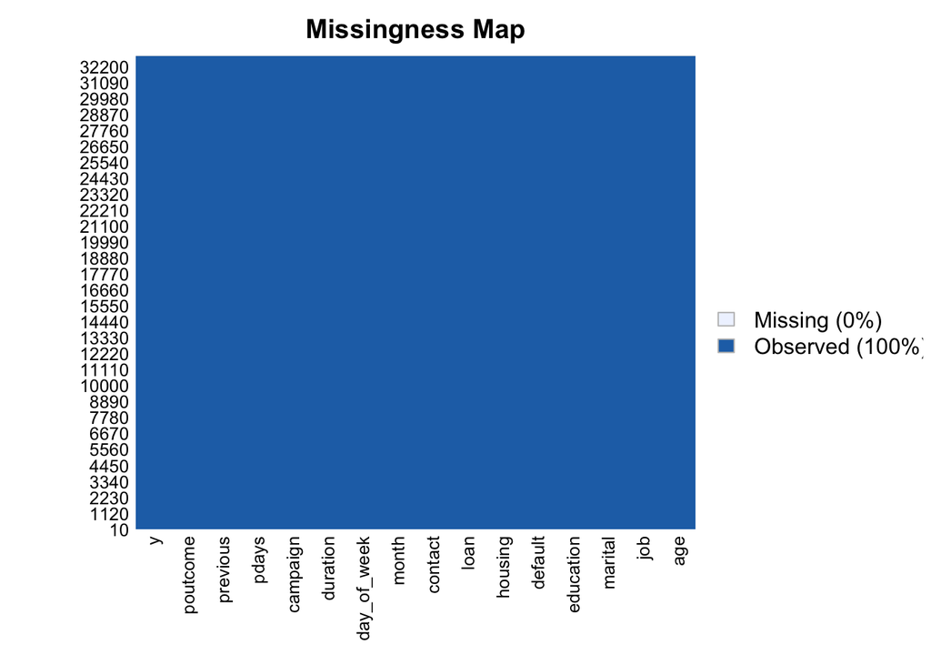

```r
missmap(bank)
```

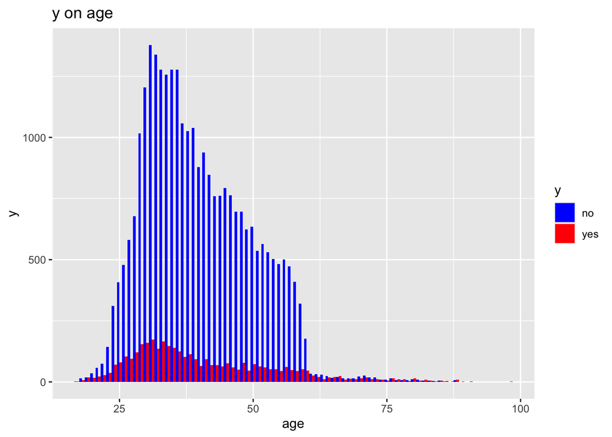

```r
bank$job=as.factor(bank$job)
bank$marital=as.factor(bank$marital)
bank$education=as.factor(bank$education)
bank$default=as.factor(bank$default)
bank$housing=as.factor(bank$housing)
bank$loan=as.factor(bank$loan)
bank$contact=as.factor(bank$contact)
bank$month=as.factor(bank$month)
bank$day_of_week=as.factor(bank$day_of_week)
bank$poutcome=as.factor(bank$poutcome)
bank$y=as.factor(bank$y)

par(mar = c(5, 4, 4, 2) + 0.1, mfrow = c(1, 1), cex = 1.2, cex.axis = 1.1, cex.lab = 1.1)

ggplot(bank, aes(x = age, fill = y)) +
  geom_histogram(position = "dodge", binwidth = 1) +
  ggtitle("y on age") +
  xlab("age") +
  ylab("y") +
  scale_fill_manual(values = c("blue", "red"))
```

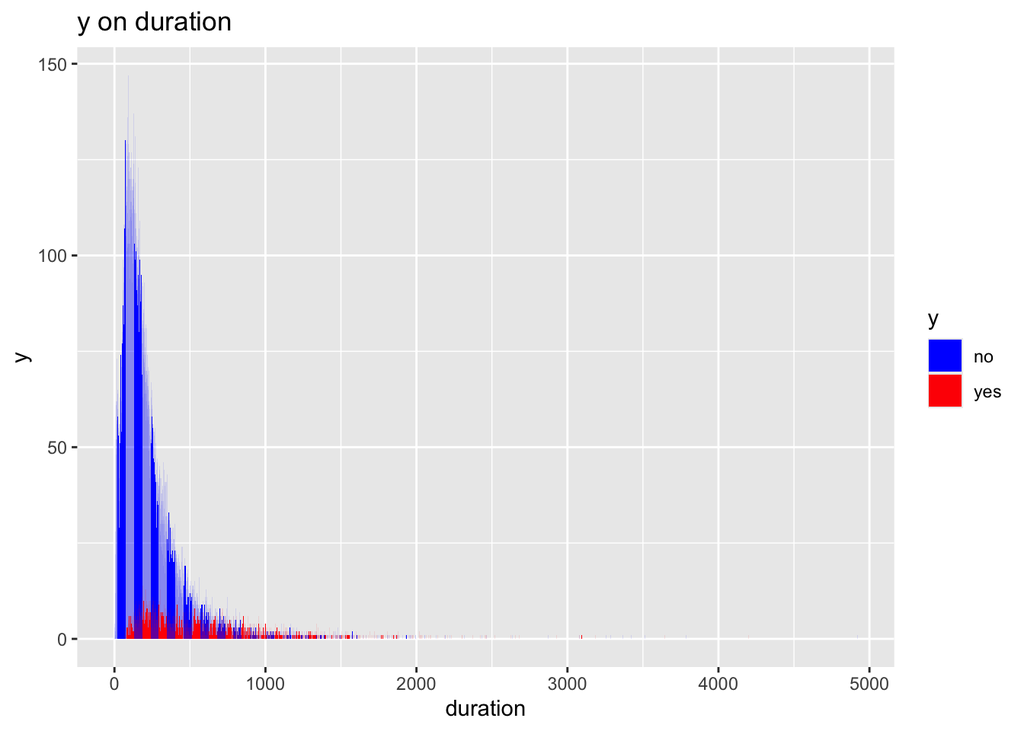

```r
ggplot(bank, aes(x = duration, fill = y)) +
  geom_histogram(position = "dodge", binwidth = 1) +
  ggtitle("y on duration") +
  xlab("duration") +
  ylab("y") +
  scale_fill_manual(values = c("blue", "red"))
```

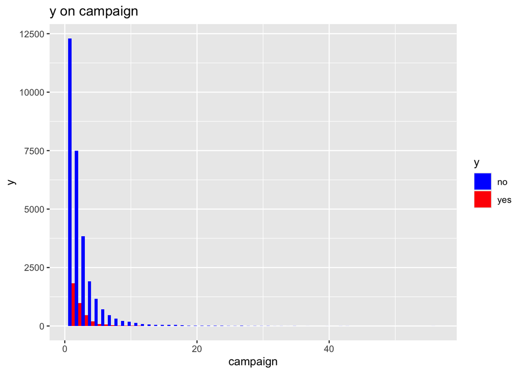

```r
ggplot(bank, aes(x = campaign, fill = y)) +
  geom_histogram(position = "dodge", binwidth = 1) +
  ggtitle("y on campaign") +
  xlab("campaign") +
  ylab("y") +
  scale_fill_manual(values = c("blue", "red"))
```

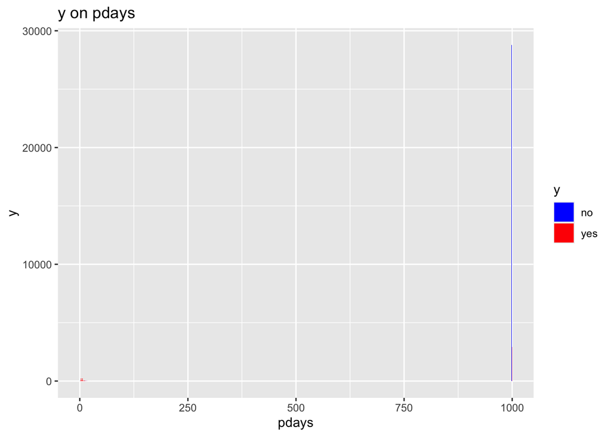

```r
ggplot(bank, aes(x = pdays, fill = y)) +
  geom_histogram(position = "dodge", binwidth = 1) +
  ggtitle("y on pdays") +
  xlab("pdays") +
  ylab("y") +
  scale_fill_manual(values = c("blue", "red"))
```

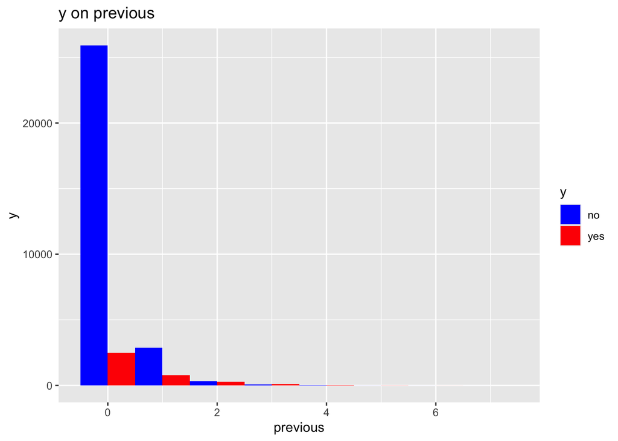

```r
ggplot(bank, aes(x = previous, fill = y)) +
  geom_histogram(position = "dodge", binwidth = 1) +
  ggtitle("y on previous") +
  xlab("previous") +
  ylab("y") +
  scale_fill_manual(values = c("blue", "red"))
```

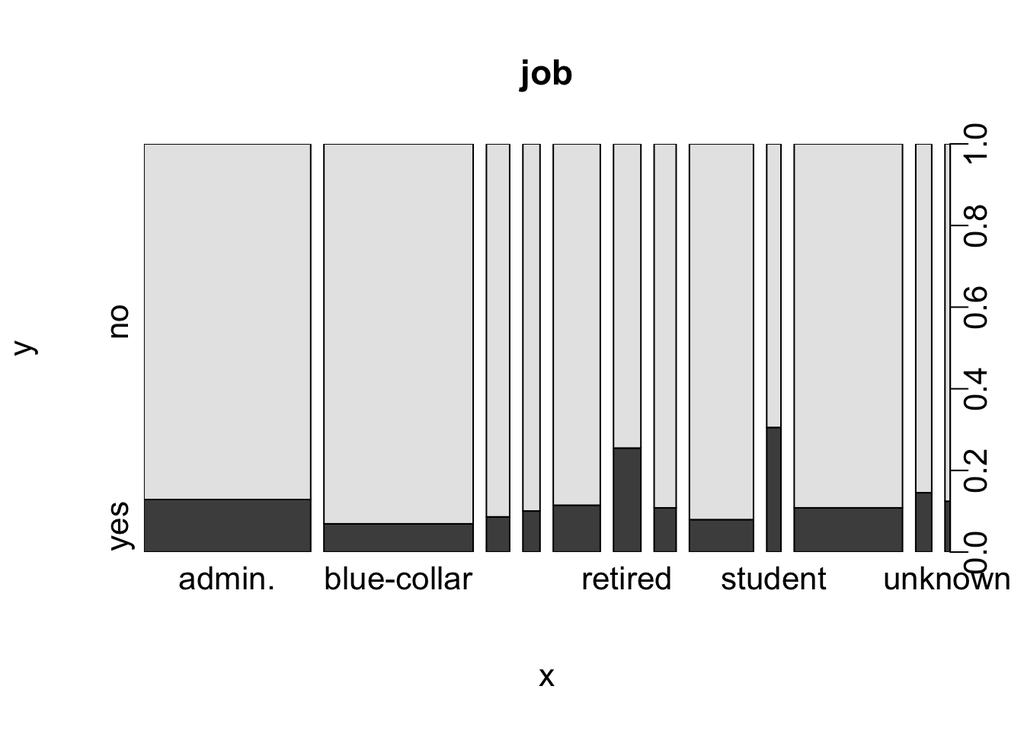

```r
plot(bank$job,bank$y,main = "job")
```

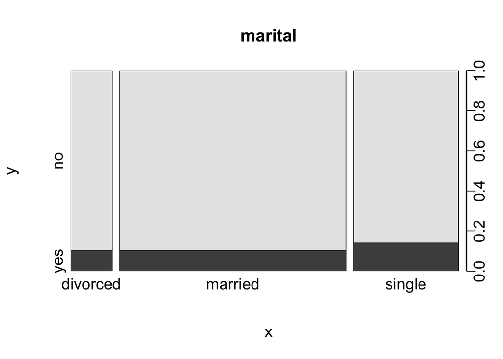

```r
plot(bank$marital,bank$y,main = "marital")
```

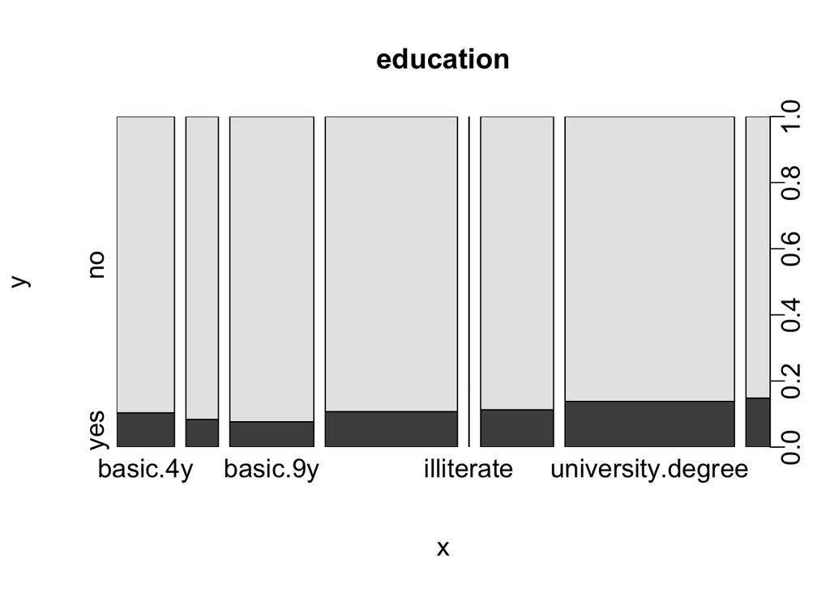

```r
plot(bank$education,bank$y,main = "education")
```

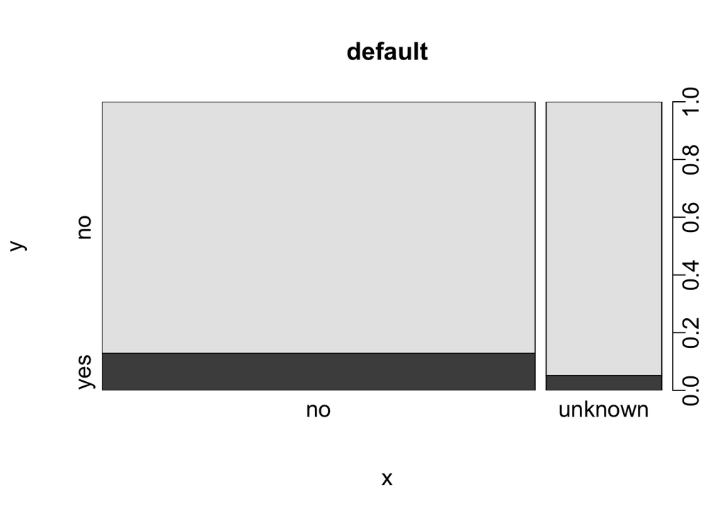

```r
plot(bank$default,bank$y,main = "default")
```

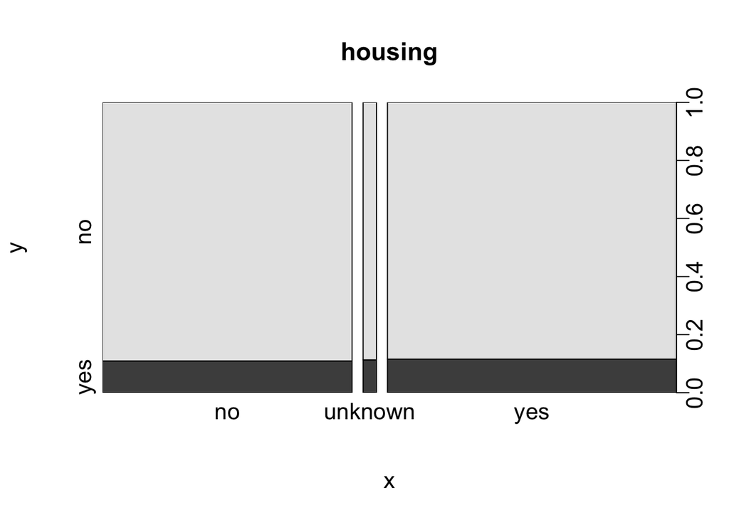

```r
plot(bank$housing,bank$y,main = "housing")
```

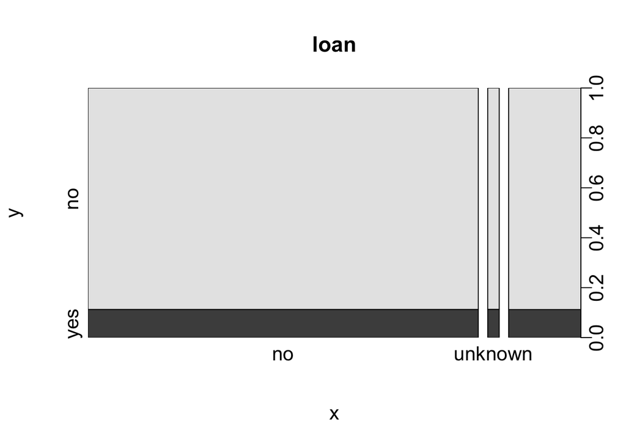

```r
plot(bank$loan,bank$y,main = "loan")
```

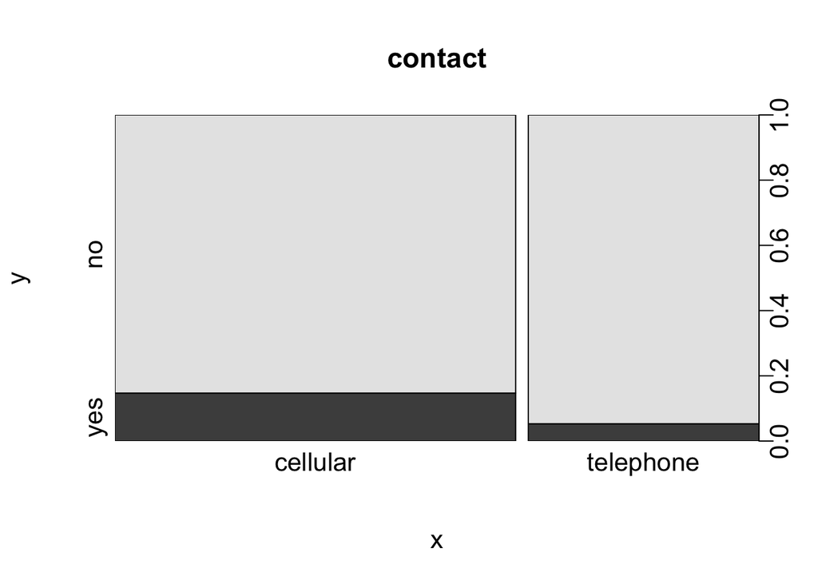

```r
plot(bank$contact,bank$y,main = "contact")
```

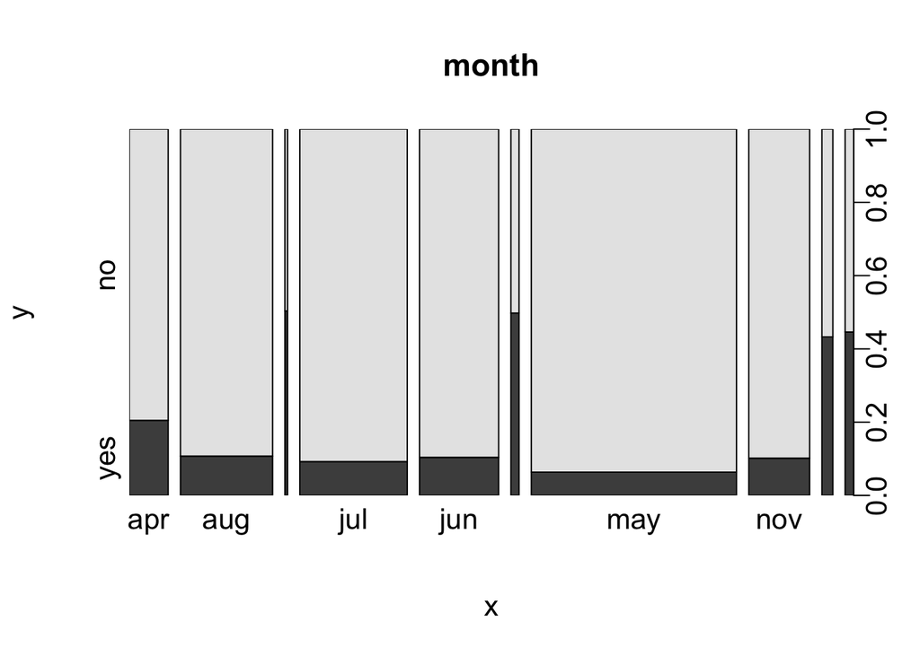

```r
plot(bank$month,bank$y,main = "month")
```

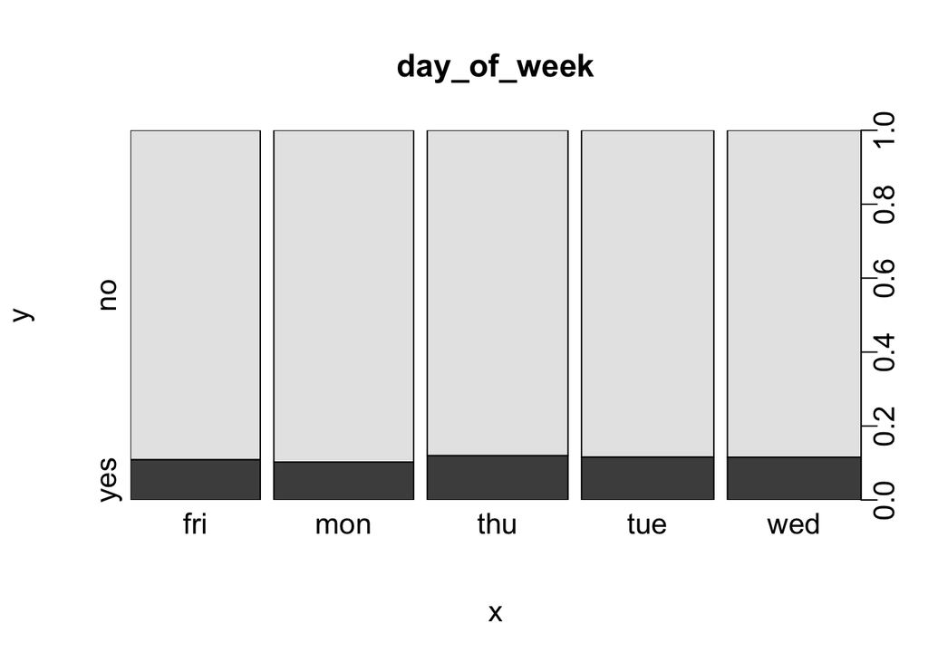

```r
plot(bank$day_of_week,bank$y,main = "day_of_week")
```